# Analysis of factors affecting red wine quality

Chlorides is right-skewed distributed with a lot of outliers located at right side and a little bit at left side.To improve the plot, I just removed the top 5% outliers. Then I used log transformation.

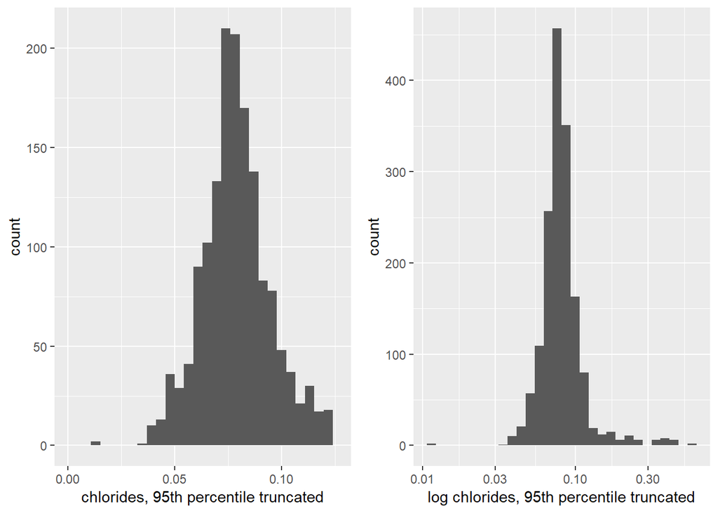

```r
p_chlorides <- ggplot(data = red_wine, aes(x=chlorides)) + geom_histogram() +
  scale_x_continuous(lim = c(0, quantile(red_wine$chlorides, 0.95))) +
  xlab('chlorides, 95th percentile truncated')
p_chlorides_log <- p_chlorides + scale_x_log10() + xlab('log chlorides, 95th percentile truncated')
grid.arrange(p_chlorides, p_chlorides_log, ncol = 2)
```

**Sulphates**

Sulphates is right-skewed distributed with a lot of outliers located at right side and a little bit at left side.To improve the plot, I just removed the top 5% outliers.

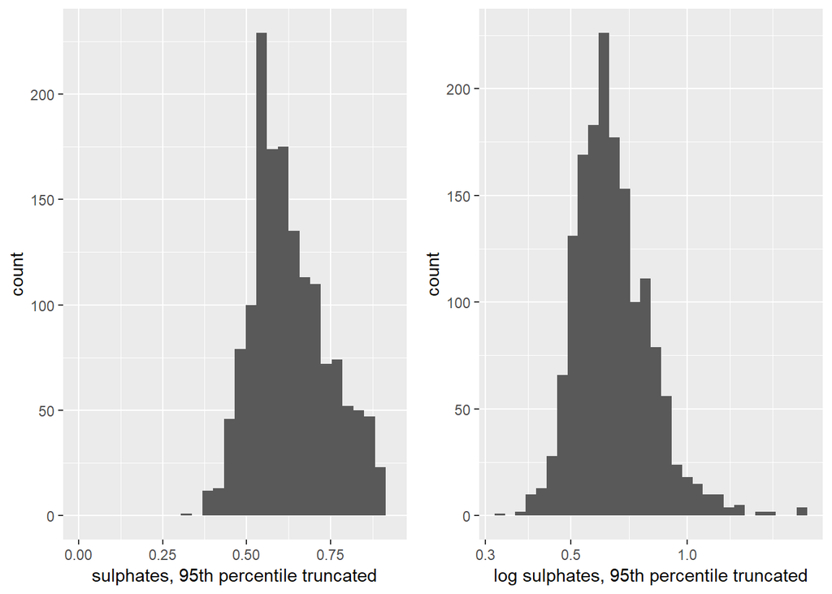

```r
p_sulphates <- ggplot(data = red_wine, aes(x=sulphates)) + geom_histogram() +
  scale_x_continuous(lim = c(0, quantile(red_wine$sulphates, 0.95))) +
  xlab('sulphates, 95th percentile truncated')
p_sulphates_log <- p_sulphates + scale_x_log10() + xlab('log sulphates, 95th percentile truncated')
grid.arrange(p_sulphates, p_sulphates_log, ncol = 2)
```

**Free Sulfur Dioxide**

Free sulfur dioxide is right-skewed without too many ourliers. To improve the plot, I just removed the top 1% outliers and use log transformation.

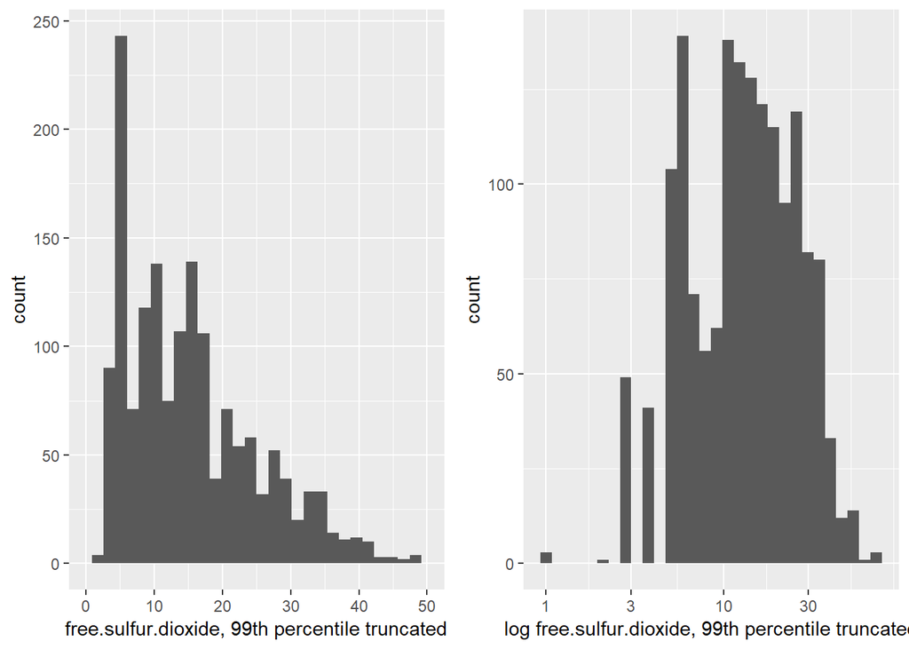

```r
p_free.sulfur.dioxide <- ggplot(data = red_wine, aes(x=free.sulfur.dioxide)) + geom_histogram() +
  scale_x_continuous(lim = c(0, quantile(red_wine$free.sulfur.dioxide, 0.99))) +
  xlab('free.sulfur.dioxide, 99th percentile truncated')
p_free.sulfur.dioxide_log <- p_free.sulfur.dioxide + scale_x_log10() + xlab('log free.sulfur.dioxide, 99th percentile truncated')
grid.arrange(p_free.sulfur.dioxide, p_free.sulfur.dioxide_log, ncol = 2)
```

**Total Sulfur Dioxide**

Total sulfur dioxide is right-skewed without too many ourliers. To improve the plot, I just removed the top 1% outliers and use log transformation.

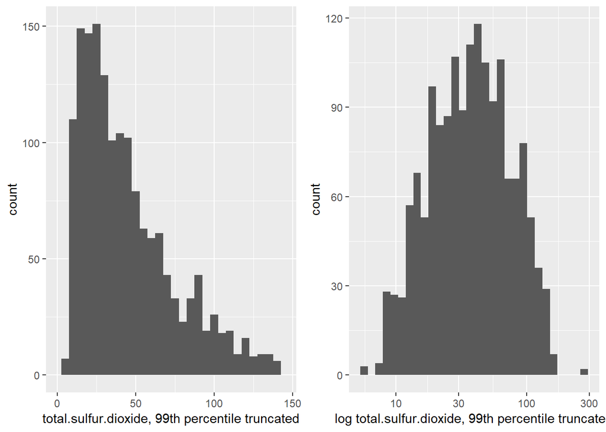

```r
p_total.sulfur.dioxide <- ggplot(data = red_wine, aes(x=total.sulfur.dioxide)) + geom_histogram() +
  scale_x_continuous(lim = c(0, quantile(red_wine$total.sulfur.dioxide, 0.99))) +
  xlab('total.sulfur.dioxide, 99th percentile truncated')
p_total.sulfur.dioxide_log <- p_total.sulfur.dioxide + scale_x_log10() + xlab('log total.sulfur.dioxide, 99th percentile truncated')
grid.arrange(p_total.sulfur.dioxide, p_total.sulfur.dioxide_log, ncol = 2)
```

**Alcohol**

Alcohol is right-skewed without too many ourliers. To improve the plot, I just removed the top 1% outliers and use log transformation.

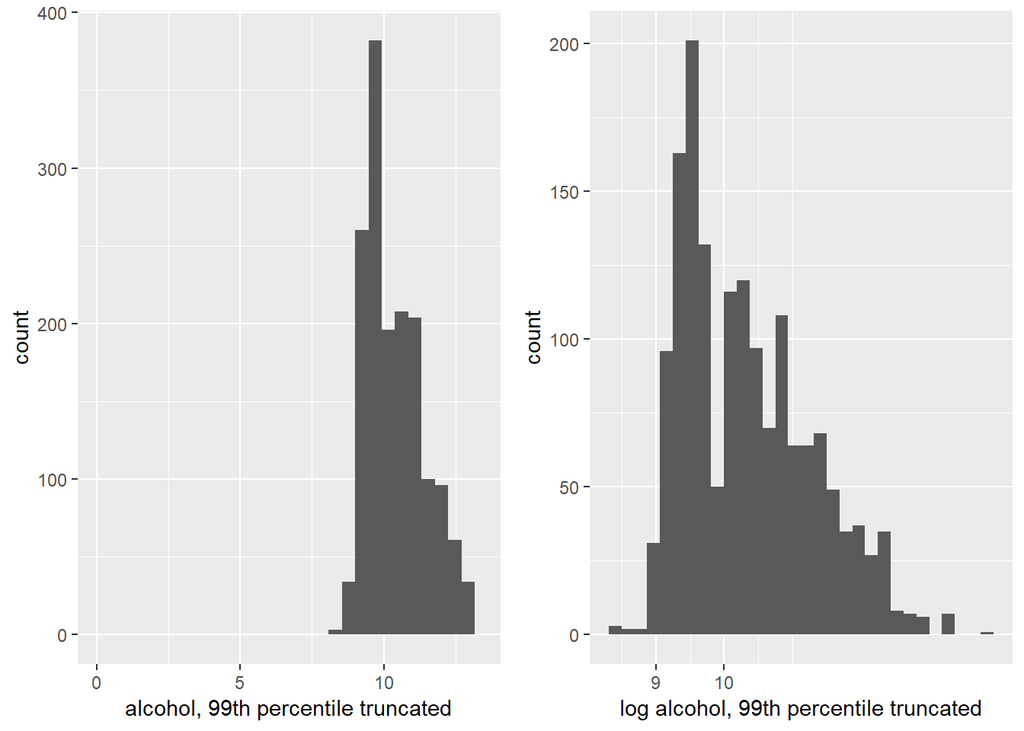

```r
p_alcohol <- ggplot(data = red_wine, aes(x=alcohol)) + geom_histogram() +
  scale_x_continuous(lim = c(0, quantile(red_wine$alcohol, 0.99))) +
  xlab('alcohol, 99th percentile truncated')
p_alcohol_log <- p_alcohol + scale_x_log10() + xlab('log alcohol, 99th percentile truncated')
grid.arrange(p_alcohol, p_alcohol_log, ncol = 2)
```

After the transformation, the distributions of each variable are shown below, which look better than original ones.

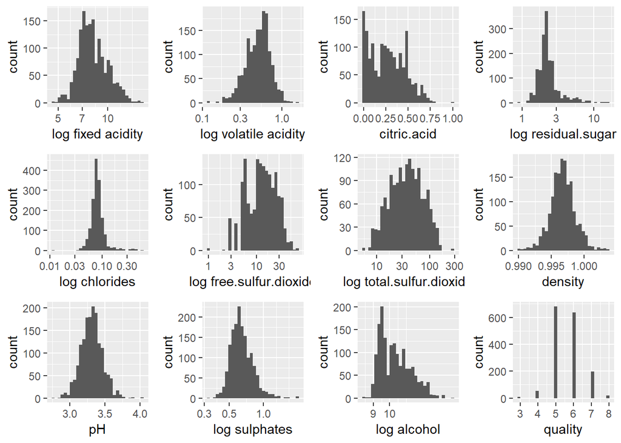

```r
grid.arrange(p_fixed.acidity_log,
             p_volatile.acidity_log,
             qplot(red_wine$citric.acid, xlab = 'citric.acid', ylab = 'count'),
             p_residual.sugar_log + xlab('log residual.sugar'),
             p_chlorides_log + xlab('log chlorides'),
             p_free.sulfur.dioxide_log + xlab('log free.sulfur.dioxide'),
             p_total.sulfur.dioxide_log + xlab('log total.sulfur.dioxide'),
             qplot(red_wine$density, xlab = 'density', ylab = 'count'),
             qplot(red_wine$pH, xlab = 'pH', ylab = 'count'),
             p_sulphates_log + xlab('log sulphates'),
             p_alcohol_log + xlab('log alcohol'),
             qplot(red_wine$quality, xlab = 'quality', ylab = 'count'),
             ncol = 4)
```

# Feature Engineering: Part II

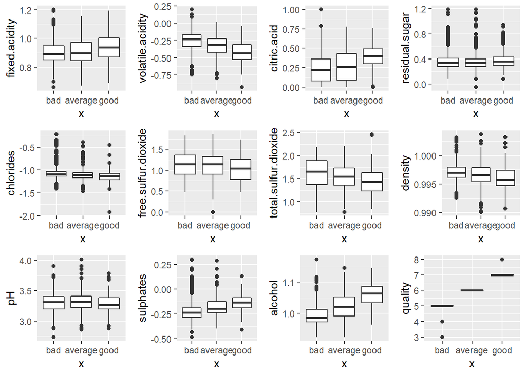

```r
# create a function to draw bivariate boxplots
boxplot_bivariate <- function(x, y, ylab) {
  return(qplot(data = red_wine, x = x, y = y, geom = 'boxplot', ylab = ylab))
}

grid.arrange(boxplot_bivariate(red_wine$rating, log10(red_wine$fixed.acidity), 'fixed.acidity'),
             boxplot_bivariate(red_wine$rating, log10(red_wine$volatile.acidity), 'volatile.acidity'),
             boxplot_bivariate(red_wine$rating, red_wine$citric.acid, 'citric.acid'),
             boxplot_bivariate(red_wine$rating, log10(red_wine$residual.sugar), 'residual.sugar'),
             boxplot_bivariate(red_wine$rating, log10(red_wine$chlorides), 'chlorides'),
             boxplot_bivariate(red_wine$rating, log10(red_wine$free.sulfur.dioxide), 'free.sulfur.dioxide'),
             boxplot_bivariate(red_wine$rating, log10(red_wine$total.sulfur.dioxide), 'total.sulfur.dioxide'),
             boxplot_bivariate(red_wine$rating, red_wine$density, 'density'),
             boxplot_bivariate(red_wine$rating, red_wine$pH, 'pH'),
             boxplot_bivariate(red_wine$rating, log10(red_wine$sulphates), 'sulphates'),
             boxplot_bivariate(red_wine$rating, log10(red_wine$alcohol), 'alcohol'),
             boxplot_bivariate(red_wine$rating, red_wine$quality, 'quality'),
             ncol = 4)
```

From exploring these plots, it seems that a ‘good’ wine generally has these trends:

- higher fixed acidity and citric acid
- lower volatile acidity
- lower pH (i.e. more acidic)
- higher sulphates
- higher alcohol
- to a lesser extent, lower chlorides and lower density

Residual sugar and sulfur dioxides did not seem to have a dramatic impact on the quality or rating of the wines. Interestingly, it appears that different types of acid affect wine quality differently.

## Correlations

By utilizing cor.test, I calculated the correlation for each of these variables against quality.

```r
correlations <- c(cor(red_wine$quality, log10(red_wine$fixed.acidity)),
                  cor(red_wine$quality, log10(red_wine$volatile.acidity)),
                  cor(red_wine$quality, red_wine$citric.acid),
                  cor(red_wine$quality, log10(red_wine$residual.sugar)),
                  cor(red_wine$quality, log10(red_wine$chlorides)),
                  cor(red_wine$quality, log10(red_wine$free.sulfur.dioxide)),
                  cor(red_wine$quality, log10(red_wine$total.sulfur.dioxide)),
                  cor(red_wine$quality, red_wine$density),
                  cor(red_wine$quality, red_wine$pH),
                  cor(red_wine$quality, log10(red_wine$sulphates)),
                  cor(red_wine$quality, log10(red_wine$alcohol)))
names(correlations) <- c('log.fixed.acidity', 'log.volatile.acidity', 'citric.acid',
                         'log.residual.sugar', 'log.chlordies',
                         'log.free.sulfur.dioxide', 'log.total.sulfur.dioxide',
                         'density', 'pH',
                         'log.sulphates', 'log.alcohol')
correlations
```

```
##        log.fixed.acidity     log.volatile.acidity              citric.acid
##               0.11423756              -0.39124918               0.22637251
##       log.residual.sugar            log.chlordies  log.free.sulfur.dioxide
##               0.02353331              -0.17613996              -0.05008749
## log.total.sulfur.dioxide                  density                       pH
##              -0.17014272              -0.17491923              -0.05773139
##            log.sulphates              log.alcohol
##               0.30864193               0.47698109
```

## PCA and K-means Clustering

Next, I did principal component analysis to this dataset.

```r
# data update
new_red <- red_wine
new_red$fixed.acidity <- log10(new_red$fixed.acidity)
new_red$volatile.acidity <- log10(new_red$volatile.acidity+1)
new_red$citric.acid <- new_red$citric.acid
new_red$residual.sugar <- log10(new_red$residual.sugar)
new_red$chlorides <- log10(new_red$chlorides+1)
new_red$free.sulfur.dioxide <- log10(new_red$free.sulfur.dioxide)
new_red$total.sulfur.dioxide <- log10(new_red$total.sulfur.dioxide)
new_red$density <- new_red$density
new_red$pH <- new_red$pH
new_red$sulphates <- log10(new_red$sulphates+1)
new_red$alcohol <- log10(new_red$alcohol)
```

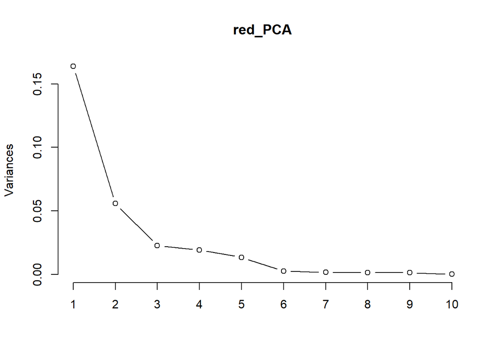

```r
# PCA
red_PCA = prcomp(new_red[, 1:11])
plot(red_PCA, type = 'l')
```

```r
summary(red_PCA)
```

```
## Importance of components:
##                           PC1    PC2     PC3     PC4     PC5     PC6
## Standard deviation     0.4046 0.2363 0.15072 0.13864 0.11589 0.05162
## Proportion of Variance 0.5804 0.1980 0.08053 0.06813 0.04761 0.00944
## Cumulative Proportion  0.5804 0.7784 0.85889 0.92703 0.97464 0.98408
##                            PC7     PC8     PC9    PC10      PC11
## Standard deviation     0.04049 0.03685 0.03609 0.01375 0.0007052
## Proportion of Variance 0.00581 0.00481 0.00462 0.00067 0.0000000
## Cumulative Proportion  0.98990 0.99471 0.99933 1.00000 1.0000000
```

Here we can see that, the first 4 components can explain more than 90% of the variation.

```r
red_wine_pca <- predict(red_PCA, newdata = new_red)
red_wine_pca <- as.data.frame(red_wine_pca)
red_wine_pca[ , 12] <- as.data.frame(new_red$quality)
colnames(red_wine_pca)[12] <- "quality"
red_wine_pca[ , 13] <- as.data.frame(new_red$rating)
colnames(red_wine_pca)[13] <- "rating"
red_wine_cluster <- red_wine_pca[, c(1,2,3,4)]
```

Next, I tried to classify the dataset based on these 4 PCs to see whether the clusters can match the quality.

[figure not shown]

```r
library(factoextra)
mydata_st <- red_wine_cluster
k2 <- kmeans(mydata_st, centers = 2, nstart = 25)
plot_k2 <- fviz_cluster(k2, geom = "point", data = mydata_st) + ggtitle("k = 2")
k3 <- kmeans(mydata_st, centers = 3, nstart = 25)
plot_k3 <- fviz_cluster(k3, geom = "point", data = mydata_st) + ggtitle("k = 3")
k4 <- kmeans(mydata_st, centers = 4, nstart = 25)
plot_k4 <- fviz_cluster(k4, geom = "point", data = mydata_st) + ggtitle("k = 4")
k5 <- kmeans(mydata_st, centers = 5, nstart = 25)
plot_k5 <- fviz_cluster(k5, geom = "point", data = mydata_st) + ggtitle("k = 5")
k6 <- kmeans(mydata_st, centers = 6, nstart = 25)
plot_k6 <- fviz_cluster(k6, geom = "point", data = mydata_st) + ggtitle("k = 6")
k7 <- kmeans(mydata_st, centers = 7, nstart = 25)
plot_k7 <- fviz_cluster(k6, geom = "point", data = mydata_st) + ggtitle("k = 7")
grid.arrange(plot_k2, plot_k3, plot_k4, plot_k5, plot_k6, plot_k7, nrow = 2)
```

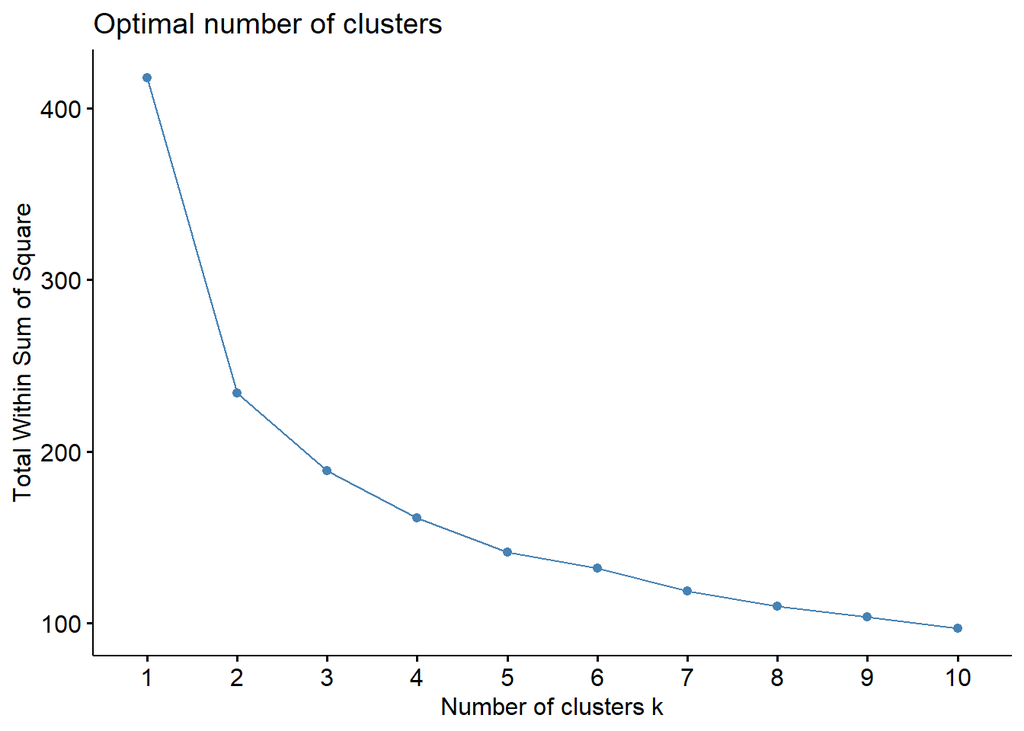

```r
# Determine the optimal number of clusters
set.seed(123)
fviz_nbclust(mydata_st, kmeans, method = "wss")
```

We can see that both situation of k = 2 and situation of k = 3 show good visual results.

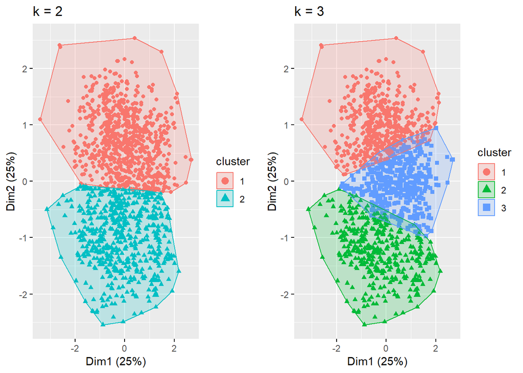

```r
grid.arrange(plot_k2, plot_k3, nrow = 1)
```

# Modeling

```r
# train data and test data
library(caTools)
set.seed(123)
spl = sample.split(red_wine_pca$rating, SplitRatio = 0.7)
redtrain = subset(red_wine_pca, spl==TRUE)
redtest = subset(red_wine_pca, spl==FALSE)
```

## Ordinal Logistic Regression Model

```r
library(MASS)
library(reshape2)
red_ordinal <- polr(rating ~ PC1 + PC2 + PC3 + PC4,
                    data = redtrain)
red_ordinal_pred <- predict(red_ordinal, redtest, type = "class")
table(red_ordinal_pred, redtest$rating)
```

```
##
## red_ordinal_pred bad average good
##          bad     145      81   17
##          average  78     110   48
##          good      0       0    0
```

```r
# accuracy
(145+110+0)/nrow(redtest)
```

```
## [1] 0.5323591
```

```r
red_ordinal <- polr(rating ~ PC1 + PC2 + PC3 + PC4 + PC5,
                    data = redtrain)
red_ordinal_pred <- predict(red_ordinal, redtest, type = "class")
table(red_ordinal_pred, redtest$rating)
```

```
##
## red_ordinal_pred bad average good
##          bad     144      84   14
##          average  79     107   51
##          good      0       0    0
```

```r
# accuracy
(144+107+0)/nrow(redtest)
```

```
## [1] 0.5240084
```

## Decision Tree Model

```r
library(rpart)
red_tree = rpart(rating ~ PC1 + PC2 + PC3 + PC4,
                 data = redtrain, method = "class")
red_tree_pred <- predict(red_tree, redtest, type = "class")
table(red_tree_pred, redtest$rating)
```

```
##
## red_tree_pred bad average good
##       bad     145      70   19
##       average  78     121   46
##       good      0       0    0
```

```r
# accuracy
(145+121+0)/nrow(redtest)
```

```
## [1] 0.5553236
```

```r
red_tree = rpart(rating ~ PC1 + PC2 + PC3 + PC4 + PC5,
                 data = redtrain, method = "class")
red_tree_pred <- predict(red_tree, redtest, type = "class")
table(red_tree_pred, redtest$rating)
```

```
##
## red_tree_pred bad average good
##       bad     147      73   17
##       average  65      81   28
##       good     11      37   20
```

```r
# accuracy
(147+81+20)/nrow(redtest)
```

```
## [1] 0.5177453
```

## Random Forest Model

```r
library("randomForest")
red_forest = randomForest(rating ~ PC1 + PC2 + PC3 + PC4,
                          data = redtrain)
red_forest_pred <- predict(red_forest, redtest, type = "class")
table(red_forest_pred, redtest$rating)
```

```
##
## red_forest_pred bad average good
##         bad     161      64   13
##         average  54     111   24
##         good      8      16   28
```

```r
# accuracy
(161+111+28)/nrow(redtest)
```

```
## [1] 0.6263048
```

```r
red_forest = randomForest(rating ~ PC1 + PC2 + PC3 + PC4 + PC5,
                          data = redtrain)
red_forest_pred <- predict(red_forest, redtest, type = "class")
table(red_forest_pred, redtest$rating)
```

```
##
## red_forest_pred bad average good
##         bad     168      62   14
##         average  51     114   20
##         good      4      15   31
```

```r
# accuracy
(168+114+31)/nrow(redtest)
```

```
## [1] 0.6534447
```

# Conclusions

The two main findings through the project is about PCA and models. The viewpoint of the more PCs we choose, the better performance we will get is **not right**. In these three models, I compared the performances of choosing 4 PCs and 5 PCs respectively, only the random forest model provided a little better performance when choosing 5 PCs, the other two models performed better when choosing 4 PCs. After comparing the performances of three models, I found that **random forest** model is the best model to predict red wine quality according to wine chemical properties, as the accuracy rates exceed 60%. Decision tree model and ordinal logistic regression model performed similarly, only a little higher than 50% accuracy.